# WVS: What Makes People Happy?

Team 3 (*Blinding Insight*) / Rostock Retreat

June 27, 2017

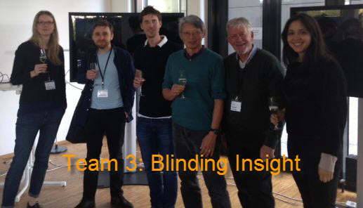

## World Value Survey

At the [Rostock Retreat 2017](http://www.rostock-retreat.org/2017/), our team was assigned to analyze data from the 6th wave of the World Value Survey, http://www.worldvaluessurvey.org/WVSDocumentationWV6.jsp. The vague instructions were:

> Run analyses on this dataset related to a one or a few research questions which you are free to choose. Ideally you should conduct both descriptive analyses as well as specify models. The outcomes shall be presented in visualized form.

## Preliminaries

Ugh! The dataset was provided as an `.rdata` file that had been exported from some other software (SPSS?). The variables were named `V1` … `V263`, and there was a separate Codebook, in Excel format, giving the survey questions and the coding of responses.

There was a lot (too much!) of work just to make this comprehensible and remove observations with a variety of missing value codes.

The original data set had 90,350 observations and 430 variables. We pick up here with a subset data set of 81,284 observations and 12 variables.

```r
folder <- file.path(myutil::dropbox_folder(), "Documents", "6135", "R", "WVS")
setwd(folder)
load(file.path(folder, "WVS6.RData"))
names(WVS)
```

```
##  [1] "Country_Code" "Happiness"    "Health"       "Life_sat"     "Marital"      "Kids"         "Social_class"
##  [8] "Income"       "Sex"          "Age"          "Education"    "Country"
```

Load the main packages we’ll be using:

```r
library(dplyr)
library(ggplot2)
library(tidyr)
library(magrittr)
library(corrplot)
```

### Recoding

Some of our variables of interest were coded on 1-4 or 1-5 scales, where `1` means highest. For interpretability, we reverse these scales so that a larger number means more.

```r
WVS <- WVS %>%
        mutate(Happiness =    5-Happiness,
               Health =       5-Health,
               Social_class = 6-Social_class)
WVS <- WVS %>% as_tibble()

WVS
```

```
## # A tibble: 81,284 x 12
##    Country_Code Happiness Health Life_sat Marital  Kids Social_class Income Sex      Age Education Country
##           <int>     <dbl>  <dbl>    <int> <fct>   <int>        <dbl>  <int> <fct>  <int>     <int> <chr>
##  1           12        3.     4.        8 single      0           2.      5 male      21         7 Algeria
##  2           12        3.     3.        5 single      0           3.      6 female    24         7 Algeria
##  3           12        3.     3.        4 single      0           2.      6 female    26         5 Algeria
##  4           12        3.     4.        8 single      0           2.      5 female    28         6 Algeria
##  5           12        4.     2.        8 married     3           3.      7 female    35         3 Algeria
##  6           12        3.     4.        7 married     2           3.      5 male      36         8 Algeria
##  7           12        3.     3.        7 married     4           3.      7 male      41         6 Algeria
##  8           12        3.     4.        5 married     2           1.      2 female    44         2 Algeria
##  9           12        3.     3.        6 married     5           2.      5 male      59         1 Algeria
## 10           12        4.     4.        5 married     7           3.      4 female    72         1 Algeria
## # ... with 81,274 more rows
```

## Country means

The data is hierarchical, in that respondents to the survey are nested within `Country`. One simple form of analyis uses just the country means

```r
WVS_mean <- WVS %>% group_by(Country_Code) %>%
  summarise(Country  =max(Country),
            Happiness=mean(Happiness),
            Health   =mean(Health),
            Age      =mean(Age),
            Life_sat =mean(Life_sat),
            Income   =mean(Income),
            Kids     =mean(Kids),
            Social_class =mean(Social_class),
            Education=mean(Education)
            )
```

It is usful to classify countries by continent. The `countrycode` package has a function that converts a variety of country code forms among one another. Without this, we would have to use a massive `recode()` statement to do these individually by country name or country code. Using `dplyr`, this is just a `mutate()` call.

```r
library(countrycode)
WVS_mean <- WVS_mean %>%
     mutate(Continent = countrycode(Country, "country.name", "continent"))
```

As a first step, we can examine the distributions of mean `Happiness` by continent.

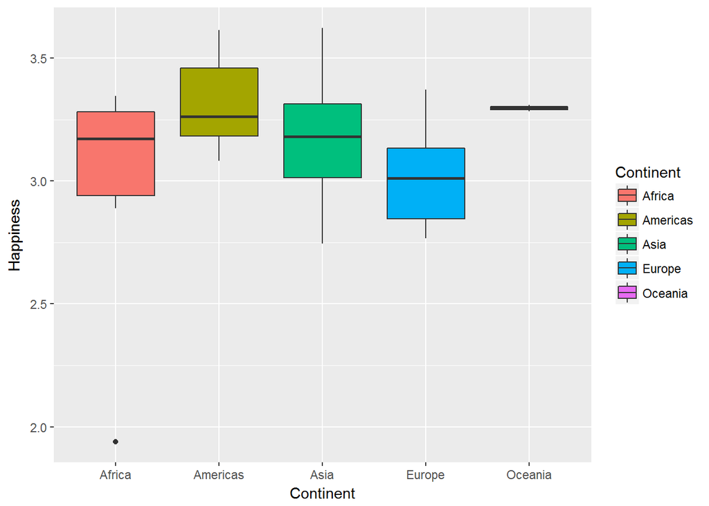

```r
ggplot(WVS_mean, aes(x=Continent, y=Happiness)) +
    geom_boxplot(aes(fill=Continent))
```